# House_price_ordinal

## Get started

```python
import numpy as np
import pandas as pd
# import scipy
import matplotlib.pyplot as plt
!pip install seaborn
import seaborn as sns

!pip install category_encoders
from category_encoders import OrdinalEncoder
from sklearn.model_selection import train_test_split

from sklearn.pipeline import Pipeline
from sklearn.preprocessing import StandardScaler
from sklearn.model_selection import GridSearchCV

from sklearn.ensemble import RandomForestRegressor
from xgboost import XGBRegressor

from sklearn.metrics import mean_squared_error
```

```python
!pip install lazypredict
import lazypredict
```

```python
from lazypredict.Supervised import LazyRegressor
```

```python
train_file_path='/content/drive/MyDrive/Colab Notebooks/House_price/train.csv'
```

## Data preparation

```python
df = pd.read_csv(train_file_path,index_col='Id')
```

```python
df.head()
```

| Id | MSSubClass | MSZoning | LotFrontage | LotArea | Street | Alley | LotShape | LandContour | Utilities | LotConfig | LandSlope | Neighborhood | Condition1 | Condition2 | BldgType | HouseStyle | OverallQual | OverallCond | YearBuilt | YearRemodAdd | RoofStyle | RoofMatl | Exterior1st | Exterior2nd | MasVnrType | MasVnrArea | ExterQual | ExterCond | Foundation | … |
| --- | --- | --- | --- | --- | --- | --- | --- | --- | --- | --- | --- | --- | --- | --- | --- | --- | --- | --- | --- | --- | --- | --- | --- | --- | --- | --- | --- | --- | --- | --- |
| 1 | 60 | RL | 65.00 | 8450 | Pave | NaN | Reg | Lvl | AllPub | Inside | Gtl | CollgCr | Norm | Norm | 1Fam | 2Story | 7 | 5 | 2003 | 2003 | Gable | CompShg | VinylSd | VinylSd | BrkFace | 196.00 | Gd | TA | PConc | … |
| 2 | 20 | RL | 80.00 | 9600 | Pave | NaN | Reg | Lvl | AllPub | FR2 | Gtl | Veenker | Feedr | Norm | 1Fam | 1Story | 6 | 8 | 1976 | 1976 | Gable | CompShg | MetalSd | MetalSd | None | 0.00 | TA | TA | CBlock | … |
| 3 | 60 | RL | 68.00 | 11250 | Pave | NaN | IR1 | Lvl | AllPub | Inside | Gtl | CollgCr | Norm | Norm | 1Fam | 2Story | 7 | 5 | 2001 | 2002 | Gable | CompShg | VinylSd | VinylSd | BrkFace | 162.00 | Gd | TA | PConc | … |
| 4 | 70 | RL | 60.00 | 9550 | Pave | NaN | IR1 | Lvl | AllPub | Corner | Gtl | Crawfor | Norm | Norm | 1Fam | 2Story | 7 | 5 | 1915 | 1970 | Gable | CompShg | Wd Sdng | Wd Shng | None | 0.00 | TA | TA | BrkTil | … |
| 5 | 60 | RL | 84.00 | 14260 | Pave | NaN | IR1 | Lvl | AllPub | FR2 | Gtl | NoRidge | Norm | Norm | 1Fam | 2Story | 8 | 5 | 2000 | 2000 | Gable | CompShg | VinylSd | VinylSd | BrkFace | 350.00 | Gd | TA | PConc | … |

```python
df.tail()
```

| Id | MSSubClass | MSZoning | LotFrontage | LotArea | Street | Alley | LotShape | LandContour | Utilities | LotConfig | LandSlope | Neighborhood | Condition1 | Condition2 | BldgType | HouseStyle | OverallQual | OverallCond | YearBuilt | YearRemodAdd | RoofStyle | RoofMatl | Exterior1st | Exterior2nd | MasVnrType | MasVnrArea | ExterQual | ExterCond | Foundation | … |
| --- | --- | --- | --- | --- | --- | --- | --- | --- | --- | --- | --- | --- | --- | --- | --- | --- | --- | --- | --- | --- | --- | --- | --- | --- | --- | --- | --- | --- | --- | --- |
| 1456 | 60 | RL | 62.00 | 7917 | Pave | NaN | Reg | Lvl | AllPub | Inside | Gtl | Gilbert | Norm | Norm | 1Fam | 2Story | 6 | 5 | 1999 | 2000 | Gable | CompShg | VinylSd | VinylSd | None | 0.00 | TA | TA | PConc | … |
| 1457 | 20 | RL | 85.00 | 13175 | Pave | NaN | Reg | Lvl | AllPub | Inside | Gtl | NWAmes | Norm | Norm | 1Fam | 1Story | 6 | 6 | 1978 | 1988 | Gable | CompShg | Plywood | Plywood | Stone | 119.00 | TA | TA | CBlock | … |
| 1458 | 70 | RL | 66.00 | 9042 | Pave | NaN | Reg | Lvl | AllPub | Inside | Gtl | Crawfor | Norm | Norm | 1Fam | 2Story | 7 | 9 | 1941 | 2006 | Gable | CompShg | CemntBd | CmentBd | None | 0.00 | Ex | Gd | Stone | … |
| 1459 | 20 | RL | 68.00 | 9717 | Pave | NaN | Reg | Lvl | AllPub | Inside | Gtl | NAmes | Norm | Norm | 1Fam | 1Story | 5 | 6 | 1950 | 1996 | Hip | CompShg | MetalSd | MetalSd | None | 0.00 | TA | TA | CBlock | … |
| 1460 | 20 | RL | 75.00 | 9937 | Pave | NaN | Reg | Lvl | AllPub | Inside | Gtl | Edwards | Norm | Norm | 1Fam | 1Story | 5 | 6 | 1965 | 1965 | Gable | CompShg | HdBoard | HdBoard | None | 0.00 | Gd | TA | CBlock | … |

df.drop(['Alley','PoolQC','Fence','MiscFeature'],axis=True,inplace=True)

```python
df.info()
```

```
<class 'pandas.core.frame.DataFrame'>
Int64Index: 1460 entries, 1 to 1460
Data columns (total 80 columns):
 #   Column         Non-Null Count  Dtype
---  ------         --------------  -----
 0   MSSubClass     1460 non-null   int64
 1   MSZoning       1460 non-null   object
 2   LotFrontage    1201 non-null   float64
 3   LotArea        1460 non-null   int64
 4   Street         1460 non-null   object
 5   Alley          91 non-null     object
 6   LotShape       1460 non-null   object
 7   LandContour    1460 non-null   object
 8   Utilities      1460 non-null   object
 9   LotConfig      1460 non-null   object
```

[output cut: 72 more lines]

```python
df.describe()
```

|  | MSSubClass | LotFrontage | LotArea | OverallQual | OverallCond | YearBuilt | YearRemodAdd | MasVnrArea | BsmtFinSF1 | BsmtFinSF2 | BsmtUnfSF | TotalBsmtSF | 1stFlrSF | 2ndFlrSF | LowQualFinSF | GrLivArea | BsmtFullBath | BsmtHalfBath | FullBath | HalfBath | BedroomAbvGr | KitchenAbvGr | TotRmsAbvGrd | Fireplaces | GarageYrBlt | GarageCars | GarageArea | WoodDeckSF | OpenPorchSF | … |
| --- | --- | --- | --- | --- | --- | --- | --- | --- | --- | --- | --- | --- | --- | --- | --- | --- | --- | --- | --- | --- | --- | --- | --- | --- | --- | --- | --- | --- | --- | --- |
| count | 1460.00 | 1201.00 | 1460.00 | 1460.00 | 1460.00 | 1460.00 | 1460.00 | 1452.00 | 1460.00 | 1460.00 | 1460.00 | 1460.00 | 1460.00 | 1460.00 | 1460.00 | 1460.00 | 1460.00 | 1460.00 | 1460.00 | 1460.00 | 1460.00 | 1460.00 | 1460.00 | 1460.00 | 1379.00 | 1460.00 | 1460.00 | 1460.00 | 1460.00 | … |
| mean | 56.90 | 70.05 | 10516.83 | 6.10 | 5.58 | 1971.27 | 1984.87 | 103.69 | 443.64 | 46.55 | 567.24 | 1057.43 | 1162.63 | 346.99 | 5.84 | 1515.46 | 0.43 | 0.06 | 1.57 | 0.38 | 2.87 | 1.05 | 6.52 | 0.61 | 1978.51 | 1.77 | 472.98 | 94.24 | 46.66 | … |
| std | 42.30 | 24.28 | 9981.26 | 1.38 | 1.11 | 30.20 | 20.65 | 181.07 | 456.10 | 161.32 | 441.87 | 438.71 | 386.59 | 436.53 | 48.62 | 525.48 | 0.52 | 0.24 | 0.55 | 0.50 | 0.82 | 0.22 | 1.63 | 0.64 | 24.69 | 0.75 | 213.80 | 125.34 | 66.26 | … |
| min | 20.00 | 21.00 | 1300.00 | 1.00 | 1.00 | 1872.00 | 1950.00 | 0.00 | 0.00 | 0.00 | 0.00 | 0.00 | 334.00 | 0.00 | 0.00 | 334.00 | 0.00 | 0.00 | 0.00 | 0.00 | 0.00 | 0.00 | 2.00 | 0.00 | 1900.00 | 0.00 | 0.00 | 0.00 | 0.00 | … |
| 25% | 20.00 | 59.00 | 7553.50 | 5.00 | 5.00 | 1954.00 | 1967.00 | 0.00 | 0.00 | 0.00 | 223.00 | 795.75 | 882.00 | 0.00 | 0.00 | 1129.50 | 0.00 | 0.00 | 1.00 | 0.00 | 2.00 | 1.00 | 5.00 | 0.00 | 1961.00 | 1.00 | 334.50 | 0.00 | 0.00 | … |
| 50% | 50.00 | 69.00 | 9478.50 | 6.00 | 5.00 | 1973.00 | 1994.00 | 0.00 | 383.50 | 0.00 | 477.50 | 991.50 | 1087.00 | 0.00 | 0.00 | 1464.00 | 0.00 | 0.00 | 2.00 | 0.00 | 3.00 | 1.00 | 6.00 | 1.00 | 1980.00 | 2.00 | 480.00 | 0.00 | 25.00 | … |
| 75% | 70.00 | 80.00 | 11601.50 | 7.00 | 6.00 | 2000.00 | 2004.00 | 166.00 | 712.25 | 0.00 | 808.00 | 1298.25 | 1391.25 | 728.00 | 0.00 | 1776.75 | 1.00 | 0.00 | 2.00 | 1.00 | 3.00 | 1.00 | 7.00 | 1.00 | 2002.00 | 2.00 | 576.00 | 168.00 | 68.00 | … |
| max | 190.00 | 313.00 | 215245.00 | 10.00 | 9.00 | 2010.00 | 2010.00 | 1600.00 | 5644.00 | 1474.00 | 2336.00 | 6110.00 | 4692.00 | 2065.00 | 572.00 | 5642.00 | 3.00 | 2.00 | 3.00 | 2.00 | 8.00 | 3.00 | 14.00 | 3.00 | 2010.00 | 4.00 | 1418.00 | 857.00 | 547.00 | … |

#### data_filter

```python
def data_filter(df):
  df.drop(['Alley','PoolQC','Fence','MiscFeature'],axis=True,inplace=True)
#numerical_cols
  if df.LotFrontage.isnull().any():
    df['LotFrontage'].fillna(method='ffill',inplace=True)
  if df.MasVnrArea.isnull().any():
    df['MasVnrArea'].fillna(value=0.0,inplace=True)
  if df.GarageYrBlt.isnull().any():
    df['GarageYrBlt'].fillna(method='ffill',inplace=True)
#obj_cols
  if df.MasVnrType.isnull().any():
    df['MasVnrType'].fillna(method='ffill',inplace=True)
  if df.BsmtQual.isnull().any():
    df['BsmtQual'].fillna(method='ffill',inplace=True)
  if df.BsmtCond.isnull().any():
    df['BsmtCond'].fillna(value='TA',inplace=True)
  if df.BsmtExposure.isnull().any():
    df['BsmtExposure'].fillna(value='No',inplace=True)
  if df.BsmtFinType1.isnull().any():
    df['BsmtFinType1'].fillna(value='Unf',inplace=True)
  if df.BsmtFinType2.isnull().any():
    df['BsmtFinType2'].fillna(value='Unf',inplace=True)
  if df.Electrical.isnull().any():
    df['Electrical'].fillna(value='SBrkr',inplace=True)

  if df.FireplaceQu.isnull().any():
    df['FireplaceQu'].iloc[0] = 'Gd'
    df['FireplaceQu'].fillna(method='ffill',inplace=True)
  if df.GarageType.isnull().any():
    df['GarageType'].fillna(method='ffill',inplace=True)
  if df.GarageFinish.isnull().any():
    df['GarageFinish'].fillna(method='ffill',inplace=True)
  if df.GarageQual.isnull().any():
    df['GarageQual'].fillna(value='TA',inplace=True)
  if df.GarageCond.isnull().any():
    df['GarageCond'].fillna(value='TA',inplace=True)


  if df.MSZoning.isnull().any():
    df['MSZoning'].fillna(value='RL',inplace=True)
  if df.Utilities.isnull().any():
    df['Utilities'].fillna(value='AllPub',inplace=True)
  if df.Exterior1st.isnull().any():
    df['Exterior1st'].fillna(value='VinylSd',inplace=True)
  if df.Exterior2nd.isnull().any():
    df['Exterior2nd'].fillna(value='VinylSd',inplace=True)
  if df.SaleType.isnull().any():
    df['SaleType'].fillna(value='WD',inplace=True)
  if df.KitchenQual.isnull().any():
    df['KitchenQual'].fillna(value='TA',inplace=True)
  if df.Functional.isnull().any():
    df['Functional'].fillna(value='Typ',inplace=True)

  if df.BsmtFinSF1.isnull().any():
    df['BsmtFinSF1'].fillna(value=439.20,inplace=True)
  if df.BsmtFinSF2.isnull().any():
    df['BsmtFinSF2'].fillna(value=52.61,inplace=True)
  if df.BsmtUnfSF.isnull().any():
    df['BsmtUnfSF'].fillna(value=554.29,inplace=True)
  if df.TotalBsmtSF.isnull().any():
    df['TotalBsmtSF'].fillna(value=1046.11,inplace=True)
  if df.BsmtFullBath.isnull().any():
    df['BsmtFullBath'].fillna(value=0.43,inplace=True)
  if df.BsmtHalfBath.isnull().any():
    df['BsmtHalfBath'].fillna(value=0.065,inplace=True)
  if df.GarageCars.isnull().any():
    df['GarageCars'].fillna(value=1.76,inplace=True)
  if df.GarageArea.isnull().any():
    df['GarageArea'].fillna(value=472.76,inplace=True)
```

```python
data_filter(df)
```

```python
#object data
s = (df.dtypes == 'object')
object_cols = list(s[s].index)
print('Categorical data : ' ,object_cols)
print('Total' , len(object_cols) )
```

```
Categorical data :  ['MSZoning', 'Street', 'LotShape', 'LandContour', 'Utilities', 'LotConfig', 'LandSlope', 'Neighborhood', 'Condition1', 'Condition2', 'BldgType', 'HouseStyle', 'RoofStyle', 'RoofMatl', 'Exterior1st', 'Exterior2nd', 'MasVnrType', 'ExterQual', 'ExterCond', 'Foundation', 'BsmtQual', …
Total 39
```

```python
#numerical data
n=((df.dtypes =='int64') | (df.dtypes =='float64'))
numerical_cols = list(n[n].index)
print('Numerical data : ' ,numerical_cols)
print('Total' , len(numerical_cols) )
```

```
Numerical data :  ['MSSubClass', 'LotFrontage', 'LotArea', 'OverallQual', 'OverallCond', 'YearBuilt', 'YearRemodAdd', 'MasVnrArea', 'BsmtFinSF1', 'BsmtFinSF2', 'BsmtUnfSF', 'TotalBsmtSF', '1stFlrSF', '2ndFlrSF', 'LowQualFinSF', 'GrLivArea', 'BsmtFullBath', 'BsmtHalfBath', 'FullBath', 'HalfBath', 'Be…
Total 37
```

## Data Visualization

```python
corr_mat=df[numerical_cols].corr()
corr_mat['SalePrice'].sort_values(ascending=True)
```

```
KitchenAbvGr    -0.14
EnclosedPorch   -0.13
MSSubClass      -0.08
OverallCond     -0.08
YrSold          -0.03
LowQualFinSF    -0.03
MiscVal         -0.02
BsmtHalfBath    -0.02
BsmtFinSF2      -0.01
3SsnPorch        0.04
MoSold           0.05
PoolArea         0.09
ScreenPorch      0.11
BedroomAbvGr     0.17
BsmtUnfSF        0.21
BsmtFullBath     0.23
LotArea          0.26
HalfBath         0.28
LotFrontage      0.30
OpenPorchSF      0.32
2ndFlrSF         0.32
WoodDeckSF       0.32
BsmtFinSF1       0.39
GarageYrBlt      0.45
Fireplaces       0.47
MasVnrArea       0.47
YearRemodAdd     0.51
YearBuilt        0.52
TotRmsAbvGrd     0.53
FullBath         0.56
1stFlrSF         0.61
TotalBsmtSF      0.61
GarageArea       0.62
GarageCars       0.64
GrLivArea        0.71
OverallQual      0.79
SalePrice        1.00
Name: SalePrice, dtype: float64
```

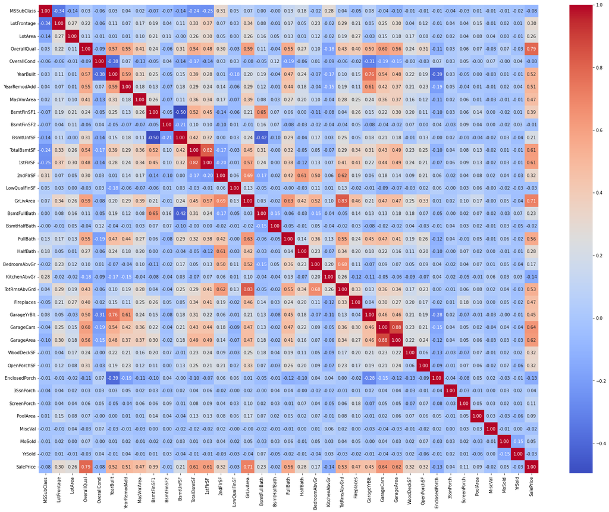

```python
plt.figure(figsize=(26,20))
sns.heatmap(df[numerical_cols].corr(),annot=True,fmt = '.2f',cmap = 'coolwarm')
```

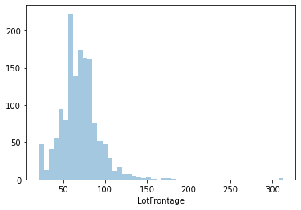

```python
#LotFrontage
sns.distplot(a=df['LotFrontage'],kde=False)
```

```python
#MasVnrArea
df['MasVnrArea'].value_counts()
```

```
0.00      869
72.00       8
180.00      8
108.00      8
120.00      7
         ...
651.00      1
337.00      1
415.00      1
293.00      1
621.00      1
Name: MasVnrArea, Length: 327, dtype: int64
```

```python
df['MasVnrArea'][df['MasVnrArea'].isnull()]
```

```
Series([], Name: MasVnrArea, dtype: float64)
```

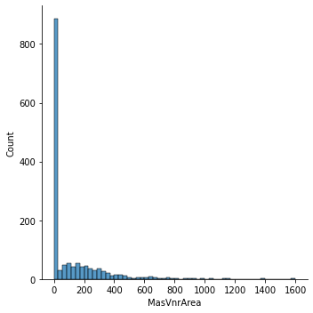

```python
sns.displot(df['MasVnrArea'],kde=False)
```

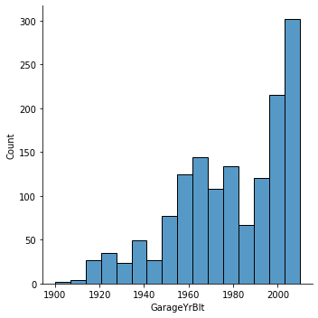

```python
#GarageCars
sns.displot(df['GarageYrBlt'],kde=False)
```

```python
df['GarageYrBlt'].describe()
```

```
count   1460.00
mean    1978.54
std       24.82
min     1900.00
25%     1961.00
50%     1980.00
75%     2002.00
max     2010.00
Name: GarageYrBlt, dtype: float64
```

```python
df[object_cols].isnull().any()
```

```
MSZoning         False
Street           False
LotShape         False
LandContour      False
Utilities        False
LotConfig        False
LandSlope        False
Neighborhood     False
Condition1       False
Condition2       False
BldgType         False
HouseStyle       False
RoofStyle        False
RoofMatl         False
Exterior1st      False
Exterior2nd      False
MasVnrType       False
ExterQual        False
ExterCond        False
Foundation       False
BsmtQual         False
BsmtCond         False
BsmtExposure     False
BsmtFinType1     False
BsmtFinType2     False
Heating          False
HeatingQC        False
CentralAir       False
Electrical       False
KitchenQual      False
Functional       False
FireplaceQu      False
GarageType       False
GarageFinish     False
GarageQual       False
GarageCond       False
PavedDrive       False
SaleType         False
SaleCondition    False
dtype: bool
```

#### InfoChart

```python
def infochart(df,feature_,chart=True):
  print('Unique values :',df[feature_].unique())
  print('Total nan     :',df[feature_].isnull().sum())
  print('Value counts  :\n',df[feature_].value_counts())
  if chart:
    plt.figure(figsize=(5,5))
    sns.displot(df[feature_],kde=False)
```

```
Unique values : ['BrkFace' 'None' 'Stone' 'BrkCmn']
Total nan     : 0
Value counts  :
 None       869
BrkFace    448
Stone      128
BrkCmn      15
Name: MasVnrType, dtype: int64
```

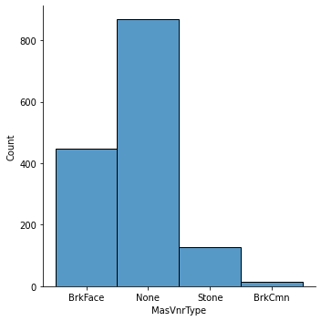

```python
#MasVnrType
infochart(df,'MasVnrType')
```

```
Unique values : ['Gd' 'TA' 'Ex' 'Fa']
Total nan     : 0
Value counts  :
 TA    664
Gd    634
Ex    123
Fa     39
Name: BsmtQual, dtype: int64
```

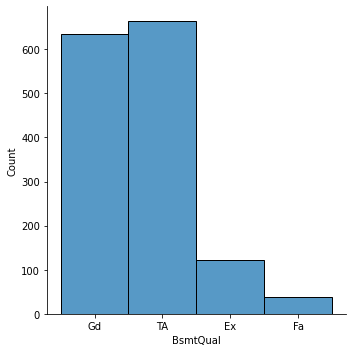

```python
#BsmtQual
infochart(df,'BsmtQual')
```

```
Unique values : ['TA' 'Gd' 'Fa' 'Po']
Total nan     : 0
Value counts  :
 TA    1348
Gd      65
Fa      45
Po       2
Name: BsmtCond, dtype: int64
```

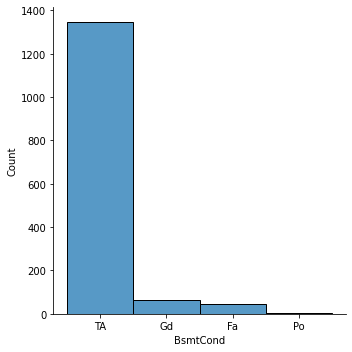

```python
# BsmtCond
infochart(df,"BsmtCond")
```

```
Unique values : ['No' 'Gd' 'Mn' 'Av']
Total nan     : 0
Value counts  :
 No    991
Av    221
Gd    134
Mn    114
Name: BsmtExposure, dtype: int64
```

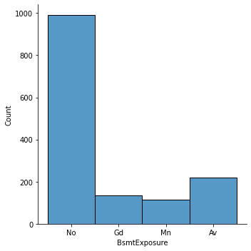

```python
# BsmtExposure
infochart(df,'BsmtExposure')
```

```
Unique values : ['GLQ' 'ALQ' 'Unf' 'Rec' 'BLQ' 'LwQ']
Total nan     : 0
Value counts  :
 Unf    467
GLQ    418
ALQ    220
BLQ    148
Rec    133
LwQ     74
Name: BsmtFinType1, dtype: int64
```

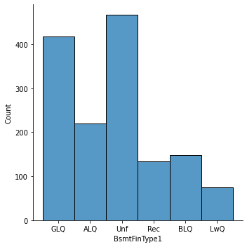

```python
# BsmtFinType1
infochart(df,'BsmtFinType1')
```

```
Unique values : ['Unf' 'BLQ' 'ALQ' 'Rec' 'LwQ' 'GLQ']
Total nan     : 0
Value counts  :
 Unf    1294
Rec      54
LwQ      46
BLQ      33
ALQ      19
GLQ      14
Name: BsmtFinType2, dtype: int64
```

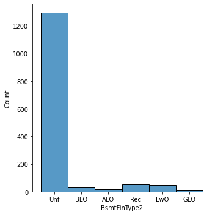

```python
# BsmtFinType2
infochart(df,'BsmtFinType2')
```

```
Unique values : ['SBrkr' 'FuseF' 'FuseA' 'FuseP' 'Mix']
Total nan     : 0
Value counts  :
 SBrkr    1335
FuseA      94
FuseF      27
FuseP       3
Mix         1
Name: Electrical, dtype: int64
```

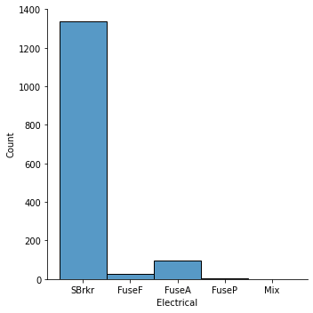

```python
# Electrical
infochart(df,'Electrical')
```

```
Unique values : ['Gd' 'TA' 'Fa' 'Ex' 'Po']
Total nan     : 0
Value counts  :
 Gd    717
TA    609
Fa     56
Po     42
Ex     36
Name: FireplaceQu, dtype: int64
```

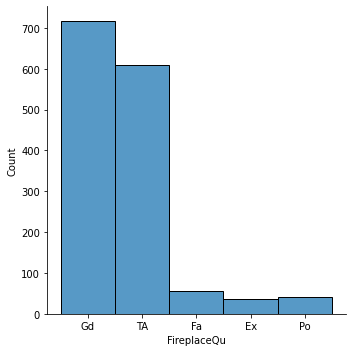

```python
# FireplaceQu
infochart(df,'FireplaceQu')
```

```
Unique values : ['Attchd' 'Detchd' 'BuiltIn' 'CarPort' 'Basment' '2Types']
Total nan     : 0
Value counts  :
 Attchd     914
Detchd     413
BuiltIn     96
Basment     22
CarPort      9
2Types       6
Name: GarageType, dtype: int64
Unique values : ['RFn' 'Unf' 'Fin']
Total nan     : 0
Value counts  :
 Unf    638
RFn    453
Fin    369
Name: GarageFinish, dtype: int64
Unique values : ['TA' 'Fa' 'Gd' 'Ex' 'Po']
Total nan     : 0
Value counts  :
 TA    1392
Fa      48
Gd      14
Po       3
Ex       3
Name: GarageQual, dtype: int64
Unique values : ['TA' 'Fa' 'Gd' 'Po' 'Ex']
Total nan     : 0
Value counts  :
 TA    1407
Fa      35
Gd       9
Po       7
Ex       2
Name: GarageCond, dtype: int64
```

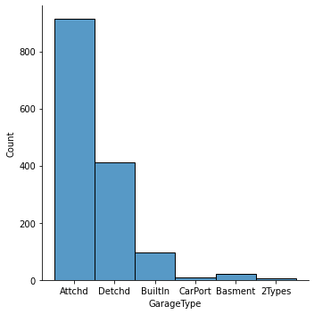

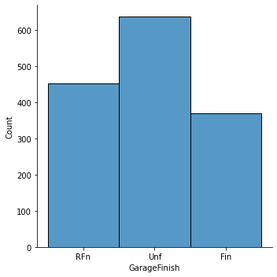

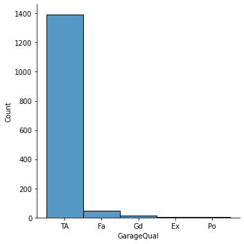

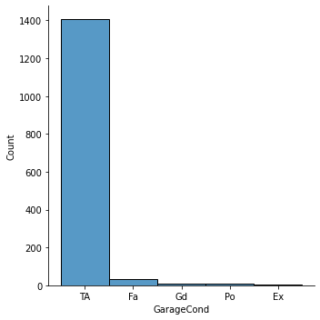

```python
infochart(df,'GarageType')
infochart(df,'GarageFinish')
infochart(df,'GarageQual')
infochart(df,'GarageCond')
```

```python
df[numerical_cols].info()
```

```
<class 'pandas.core.frame.DataFrame'>
Int64Index: 1460 entries, 1 to 1460
Data columns (total 37 columns):
 #   Column         Non-Null Count  Dtype
---  ------         --------------  -----
 0   MSSubClass     1460 non-null   int64
 1   LotFrontage    1460 non-null   float64
 2   LotArea        1460 non-null   int64
 3   OverallQual    1460 non-null   int64
 4   OverallCond    1460 non-null   int64
 5   YearBuilt      1460 non-null   int64
 6   YearRemodAdd   1460 non-null   int64
 7   MasVnrArea     1460 non-null   float64
 8   BsmtFinSF1     1460 non-null   int64
 9   BsmtFinSF2     1460 non-null   int64
```

[output cut: 29 more lines]

```python
df[object_cols].info()
```

```
<class 'pandas.core.frame.DataFrame'>
Int64Index: 1460 entries, 1 to 1460
Data columns (total 39 columns):
 #   Column         Non-Null Count  Dtype
---  ------         --------------  -----
 0   MSZoning       1460 non-null   object
 1   Street         1460 non-null   object
 2   LotShape       1460 non-null   object
 3   LandContour    1460 non-null   object
 4   Utilities      1460 non-null   object
 5   LotConfig      1460 non-null   object
 6   LandSlope      1460 non-null   object
 7   Neighborhood   1460 non-null   object
 8   Condition1     1460 non-null   object
 9   Condition2     1460 non-null   object
```

[output cut: 31 more lines]

```python
for i in df.isnull().any():
  if i:
    print(i)
```

```python
df.info()
```

```
<class 'pandas.core.frame.DataFrame'>
Int64Index: 1460 entries, 1 to 1460
Data columns (total 76 columns):
 #   Column         Non-Null Count  Dtype
---  ------         --------------  -----
 0   MSSubClass     1460 non-null   int64
 1   MSZoning       1460 non-null   object
 2   LotFrontage    1460 non-null   float64
 3   LotArea        1460 non-null   int64
 4   Street         1460 non-null   object
 5   LotShape       1460 non-null   object
 6   LandContour    1460 non-null   object
 7   Utilities      1460 non-null   object
 8   LotConfig      1460 non-null   object
 9   LandSlope      1460 non-null   object
```

[output cut: 68 more lines]

## Feature Engg.

```python
def Ordinal_en(df):
  maplist=[]
  for obj in object_cols :
    obj1={'col':obj,'mapping':{}}
    id=0
    for value in df[obj].unique():
      obj1['mapping'][value]=id
      id+=1
    maplist.append(obj1)

  ordinal_encoder = OrdinalEncoder(mapping=maplist)
  df=ordinal_encoder.fit_transform(df)
  return df
```

```python
df=Ordinal_en(df)
```

```
def OneHot_en(df):
  for obj in object_cols :
    df_Dummies = pd.get_dummies(df[obj],prefix=obj,prefix_sep='_',drop_first=False)
    for var in df_Dummies.columns:
      df[var] = df_Dummies[var]
  df.drop(object_cols,axis=True,inplace=True)
  return df
```

df = OneHot_en(df)

```python
df.head()
```

| Id | MSSubClass | MSZoning | LotFrontage | LotArea | Street | LotShape | LandContour | Utilities | LotConfig | LandSlope | Neighborhood | Condition1 | Condition2 | BldgType | HouseStyle | OverallQual | OverallCond | YearBuilt | YearRemodAdd | RoofStyle | RoofMatl | Exterior1st | Exterior2nd | MasVnrType | MasVnrArea | ExterQual | ExterCond | Foundation | BsmtQual | … |
| --- | --- | --- | --- | --- | --- | --- | --- | --- | --- | --- | --- | --- | --- | --- | --- | --- | --- | --- | --- | --- | --- | --- | --- | --- | --- | --- | --- | --- | --- | --- |
| 1 | 60 | 0 | 65.00 | 8450 | 0 | 0 | 0 | 0 | 0 | 0 | 0 | 0 | 0 | 0 | 0 | 7 | 5 | 2003 | 2003 | 0 | 0 | 0 | 0 | 0 | 196.00 | 0 | 0 | 0 | 0 | … |
| 2 | 20 | 0 | 80.00 | 9600 | 0 | 0 | 0 | 0 | 1 | 0 | 1 | 1 | 0 | 0 | 1 | 6 | 8 | 1976 | 1976 | 0 | 0 | 1 | 1 | 1 | 0.00 | 1 | 0 | 1 | 0 | … |
| 3 | 60 | 0 | 68.00 | 11250 | 0 | 1 | 0 | 0 | 0 | 0 | 0 | 0 | 0 | 0 | 0 | 7 | 5 | 2001 | 2002 | 0 | 0 | 0 | 0 | 0 | 162.00 | 0 | 0 | 0 | 0 | … |
| 4 | 70 | 0 | 60.00 | 9550 | 0 | 1 | 0 | 0 | 2 | 0 | 2 | 0 | 0 | 0 | 0 | 7 | 5 | 1915 | 1970 | 0 | 0 | 2 | 2 | 1 | 0.00 | 1 | 0 | 2 | 1 | … |
| 5 | 60 | 0 | 84.00 | 14260 | 0 | 1 | 0 | 0 | 1 | 0 | 3 | 0 | 0 | 0 | 0 | 8 | 5 | 2000 | 2000 | 0 | 0 | 0 | 0 | 0 | 350.00 | 0 | 0 | 0 | 0 | … |

```python
df.isnull().sum().any()
```

```
False
```

## Spliting train-Validation

```python
features=df.drop('SalePrice',axis=1)
label=df.pop('SalePrice')
```

df['CentralAir'].value_counts()

```python
train_X, val_X, train_y, val_y = train_test_split(features, label, random_state = 42,shuffle=True)
```

```python
print(train_X.shape,train_y.shape,val_X.shape,val_y.shape)
```

```
(1095, 75) (1095,) (365, 75) (365,)
```

## Model

```python
# params={'random_state':[None,0,42,50],
#         'n_estimators':[10,50, 70, 100, 250, 1000],
#         'min_samples_split':[1,2,5,10],
#         'min_samples_leaf':[1,2,5,10],

#         }
```

model=RandomForestRegressor(random_state=42,verbose=True)

params={'n_estimators':[10,50,100,1000]} gs=GridSearchCV(estimator=model, param_grid=params, cv=10,n_jobs = -1,verbose=1,scoring='neg_mean_squared_error') gs = gs.fit(train_X, train_y)

#### rf1

''' RMSE on train data: 10980.84433600785 RMSE on val. data: 26915.271808540667 '''

model_pipeline = Pipeline(steps=[('pre_processing',StandardScaler()), ('random_forest',RandomForestRegressor( n_estimators=100,random_state=0)) ])

### xgb

''' RMSE on train data: 18400.96228338164 RMSE on val. data: 29751.573230630336 '''

model_pipeline = Pipeline(steps=[('pre_processing',StandardScaler()), ('xgb',XGBRegressor(n_estimators=100, learning_rate=0.05, n_jobs=-1)) ])

### lazypredict

```python
stds=StandardScaler()
train_X=stds.fit_transform(train_X)
val_X=stds.fit_transform(val_X)
model_ =LazyRegressor(ignore_warnings=False, custom_metric=None)
models, predictions = model_.fit(train_X,val_X,train_y,val_y)
```

```python
models.head(20)
```

| Model | Adjusted R-Squared | R-Squared | RMSE | Time Taken |
| --- | --- | --- | --- | --- |
| GradientBoostingRegressor | 0.87 | 0.90 | 26966.87 | 0.67 |
| RandomForestRegressor | 0.87 | 0.89 | 27310.28 | 1.92 |
| ExtraTreesRegressor | 0.86 | 0.89 | 27758.51 | 1.37 |
| BaggingRegressor | 0.86 | 0.89 | 27882.81 | 0.22 |
| XGBRegressor | 0.85 | 0.88 | 28770.15 | 0.62 |
| LGBMRegressor | 0.85 | 0.88 | 28957.46 | 0.31 |
| HistGradientBoostingRegressor | 0.84 | 0.88 | 29445.63 | 1.96 |
| PoissonRegressor | 0.84 | 0.87 | 29641.65 | 0.08 |
| GammaRegressor | 0.83 | 0.87 | 30429.29 | 0.04 |
| HuberRegressor | 0.82 | 0.86 | 31269.21 | 0.19 |
| PassiveAggressiveRegressor | 0.82 | 0.86 | 31526.04 | 0.22 |
| LassoLarsIC | 0.79 | 0.83 | 34307.42 | 0.08 |
| LassoCV | 0.79 | 0.83 | 34381.32 | 0.25 |
| LassoLarsCV | 0.79 | 0.83 | 34396.42 | 0.29 |
| BayesianRidge | 0.78 | 0.83 | 34736.45 | 0.05 |
| LassoLars | 0.78 | 0.83 | 34844.89 | 0.10 |
| RidgeCV | 0.78 | 0.83 | 34874.74 | 0.03 |
| Ridge | 0.78 | 0.83 | 34923.45 | 0.02 |
| Lasso | 0.78 | 0.83 | 34942.01 | 0.08 |
| ElasticNet | 0.78 | 0.82 | 35369.09 | 0.03 |

```python
predictions.head(20)
```

| Model | Adjusted R-Squared | R-Squared | RMSE | Time Taken |
| --- | --- | --- | --- | --- |
| GradientBoostingRegressor | 0.87 | 0.90 | 26966.87 | 0.67 |
| RandomForestRegressor | 0.87 | 0.89 | 27310.28 | 1.92 |
| ExtraTreesRegressor | 0.86 | 0.89 | 27758.51 | 1.37 |
| BaggingRegressor | 0.86 | 0.89 | 27882.81 | 0.22 |
| XGBRegressor | 0.85 | 0.88 | 28770.15 | 0.62 |
| LGBMRegressor | 0.85 | 0.88 | 28957.46 | 0.31 |
| HistGradientBoostingRegressor | 0.84 | 0.88 | 29445.63 | 1.96 |
| PoissonRegressor | 0.84 | 0.87 | 29641.65 | 0.08 |
| GammaRegressor | 0.83 | 0.87 | 30429.29 | 0.04 |
| HuberRegressor | 0.82 | 0.86 | 31269.21 | 0.19 |
| PassiveAggressiveRegressor | 0.82 | 0.86 | 31526.04 | 0.22 |
| LassoLarsIC | 0.79 | 0.83 | 34307.42 | 0.08 |
| LassoCV | 0.79 | 0.83 | 34381.32 | 0.25 |
| LassoLarsCV | 0.79 | 0.83 | 34396.42 | 0.29 |
| BayesianRidge | 0.78 | 0.83 | 34736.45 | 0.05 |
| LassoLars | 0.78 | 0.83 | 34844.89 | 0.10 |
| RidgeCV | 0.78 | 0.83 | 34874.74 | 0.03 |
| Ridge | 0.78 | 0.83 | 34923.45 | 0.02 |
| Lasso | 0.78 | 0.83 | 34942.01 | 0.08 |
| ElasticNet | 0.78 | 0.82 | 35369.09 | 0.03 |

## Evalution metrix

```python
model_pipeline.fit(train_X,train_y)
```

```
---------------------------------------------------------------------------
NameError                                 Traceback (most recent call last)
<ipython-input-48-1f25e31e41ea> in <module>()
----> 1 model_pipeline.fit(train_X,train_y)

NameError: name 'model_pipeline' is not defined
```

```python
predict = model_pipeline.predict(train_X)
print('RMSE on train data: ', mean_squared_error(train_y, predict)**(0.5))
predict_val = model_pipeline.predict(val_X)
print('RMSE on val.  data: ', mean_squared_error(val_y, predict_val)**(0.5))
```

## Test

```python
test_file_path='/content/drive/MyDrive/Colab Notebooks/House_price/test.csv'
```

```python
test_df=pd.read_csv(test_file_path,index_col='Id')
```

test_df.head()

test_df.describe()

test_df.info()

```python
data_filter(test_df)
```

test_df.isnull().sum()[test_df.isnull().sum() > 0]

nan_list=test_df.isnull().sum()[test_df.isnull().sum() > 0].index

infochart(test_df,'MSZoning')

infochart(test_df,'Utilities')

infochart(test_df,'Exterior1st',chart=False)

infochart(test_df,'Exterior1st',chart=False)

infochart(test_df,'SaleType',chart=False)

infochart(test_df,'KitchenQual',chart=False)

infochart(test_df,'Functional',chart=False)

```python
test_df=Ordinal_en(test_df)
```

```
test_df=OneHot_en(test_df)
```

Test_exclude=[] for i in df.columns : if i not in test_df.columns : Test_exclude.append(i) for col in Test_exclude: test_df.loc[:,col]=0

test_df.head()

```python
predict_test = model_pipeline.predict(test_df)
```

```python
test_y=pd.DataFrame(predict_test,index=test_df.index,columns=['SalePrice'])
```

```python
test_y.to_csv('submissions_houseprice_K2_xgb.csv')
```